# Monika feasibility samples

Mike Trnka

2024-05-02

### Experiment Overview:

##### Exp1 - S20231113

- Human histones. MLA-H3K9. Assembled into Chromatin.
- PS vs nonPS.
- BS3 Crosslinked
- LysC / Trypsin digest
- TMT-zero labeling.
- PS sample was injected directly (w/o fractionation)
- nonPS sample was fractionated into 3 SEC fractions.
- Acquired MS data on 15 cm column on Exploris. No Faims.

##### Exp2 - S20240326

- Human histones. All WT. Assembled into Chromatin
- TMT labeled vs unlabeled
- BS3 Crosslinked
- LysC / LysC digestion
- TMT-zero labeling of one sample. Other is unlabeled.
- TMT sample was injected directly w/o fractionation.
- Unlabeled sample was fractionated into 4 SEC fractions.
- Acquired MS data on 50 cm column on Exploris using the FAIMS source.

*note: in all previous optimization experiments the FAIMS source gives 40%-100% more crosslinks. The 50 cm column will also give more resolving power and hence more crosslinks than the 15cm column)*

The main goals were to test the pipeline for these experiments before committing to doing a costly TMT-6plex experiment. We are mainly looking for: 1. sufficient TMT labeling to proceed with a full experiment 2. sufficient crosslinking to regions of interest within the nucleosome.

The table below has summary numbers of crosslinks from the different experiment / conditions. URPs is the number of unique residue pairs is the main thing I’m looking at. The data is classified at 5% FDR meaning that we expect 5% of the URPs to be misclassified. The text is hyperlinked and will open the list of crosslinks in MS-Viewer. In the MS-Viewer window, the “Crosslinked Peptide” column contains a link to the annotated spectrum.

numCSM = the number of spectra matched to crosslinks and includes redundant hits.

The extentTMT column calculates what percent of the available Lysines and N-termini are modified by either the TMT reagent or by the crosslinker.

| Table 1 - Crosslinks classified at 5% FDR URP sample | Table 1 - Crosslinks classified at 5% FDR URP numPPIa | Table 1 - Crosslinks classified at 5% FDR URP numURPb | Table 1 - Crosslinks classified at 5% FDR URP numCSMc | Table 1 - Crosslinks classified at 5% FDR URP extentTMTd |
| --- | --- | --- | --- | --- |
| Exp1 - NonPS | 10 | [73](https://msviewer.ucsf.edu/cgi-bin/mssearch.cgi?report_title=MS-Viewer&search_key=gtahvotgcv&search_name=msviewer) | 140 | 0.917 |
| Exp1 - PS | 9 | [48](https://msviewer.ucsf.edu/cgi-bin/mssearch.cgi?report_title=MS-Viewer&search_key=3j59gosugz&search_name=msviewer) | 66 | 0.953 |
| Exp2 - TMT | 11 | [25](https://msviewer.ucsf.edu/cgi-bin/mssearch.cgi?report_title=MS-Viewer&search_key=x7sx7p961e&search_name=msviewer) | 42 | 0.953 |
| Exp2 - Unlabeled | 8 | [51](https://msviewer.ucsf.edu/cgi-bin/mssearch.cgi?report_title=MS-Viewer&search_key=kyidqvapec&search_name=msviewer) | 184 | 0.454 |

aProtein-Protein Interactions  
bUnique Residue Pairs (crosslinks)  
cCrosslinked Spectral Matches  
dPercent Lys modified by either TMT or DSS

##### Is there enough TMT modification?

The extent of TMT modification is acceptable. In all cases where we expect TMT labels we find the extent of modification is > 90%. I would prefer it to be > 95%, but its not bad. Exp2 had an unlabeled experiment that has 45.4% modification. This is really the extent of free amines modified and in this case it means by the crosslinking reagent (not TMT), sorry for the confusing column header.

To further look at the TMT and test our ability to extract the TMT signal, I plotted the TMT values by channel:

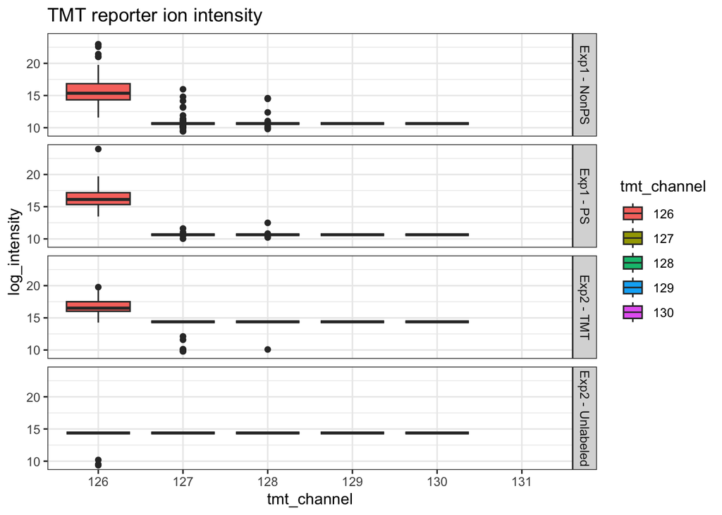

The three conditions that were TMT labeled show strong signal on the 126 channel and no signal on the other 5 channels. This is what we expect from the TMT-zero reagent. The last condition had no TMT labeling so it is expected that we don’t see any TMT signal.

So, overall, the TMT labeling aspect of the experiment looks okay.

##### Is there enough crosslinking?

Looking at the crosslinking, there are some methodological things to note:

1. Conditions that were SEC fractionated showed more crosslinking than unfractionated. This is expected, but in both experiments, I was thrown off because the UV-214nm trace was low when I ran the first condition by SEC and I elected to skip the fractionation step for the second condition.
2. The second experiment was much less successful than the first. We would expect to see more crosslinks in Exp2 becuase we using the longer 50 cm column and using the FAIMS source. Instead, we have a much number of crosslinks. Potential reason for the lower yield are

   2.a Started with less protein.

   2.b Poorer crosslinking during preparation.

   2.c Loss during sample preparation.
   - Loss due to acetone precipitation
   - Loss due to desalting step.
   - Loss due to Lys-C treatment in lieu of Trypsin.

   2.d Poorer performance of MS / Faims on day of second acquisition.

Its hard to state conclusively what the issue was with the second experiment. My initial thought is to suspect the switch to the double Lys-C digestions instead of doing one Lys-C and one Trypsin. This was motiviated by theoretical calculations that suggested that we would have the most number of optimal peptides for MS analysis from all four histones using Lys-C alone for proteolysis. Since all the other steps in the protocol are well tested and the instrument performance is assessed prior to running any samples, it seems most likely to me that the Lys-C (either in general, or the particular batch used) lead to lower proteolysis than expected. However, if this was case then we would expect there to be a large number of peptides with missed cleavages. I did an analysis of this and 87% of peptides I found in the LysC experiment were fully cleaved which is not indicative of poor proteolysis.

The performance of the instrument is always assessed by injecting a standard and comparing performance relative to historical averages. The standard looked good on the day of data acquisition. However, the standard doesn’t assess performance on crosslinked samples and doesn’t assess the FAIMs performance. As mentioned, I have run the same crosslinked samples with and without FAIMS source a number of time now and always found excellent improvement with the FAIMS. Note that this was mostly with DSSO crosslinking rather than BS3, but it seems unlikely to make much difference.

I do think the instrument is optimally tuned for the BS3 crosslinked samples. For instance, looking through the annotated spectra from both experiments, I see many examples where the dominant ion in MS2 is the unfragmented precursor peak. The product ion fragments which are necessary to identify the crosslinked peptides are typically much smaller. Here are some examples:

- bad frag 1
- bad frag 2
- bad frag 3

These examples are drawn from the TMT labeled experiments. In contrast, the experiment that did not have any TMT labeling has generally much better fragmentation:

- good frag 1
- good frag 2

So, I do think that the HCD collision energy needs to be increased when using BS3 crosslinking together with TMT. However, even in the experiment without the TMT, there is still relatively low crosslinking. This isn’t surprising, since we need to introduce enough collisional energy to fragment both the TMT reported and the peptides. The part that is surprising is that I am already using higher HCD energy to account for this and in fact, I increased it more for Exp2. But I think we would benefit from even more collisional energy. The total ion current in MS runs actually looks reasonably abundant which indicates that we do have a decent amount of protein on the column. It might be less than optimal, but I think we could be finding more crosslinks from the same samples with this methodological tweak.

##### Are we seeing enough crosslinks for the experiment?

Table 2 shows the number of crosslinks found in between core and tail histone domains. This is only data from Exp1. Compared to the maximum number of possible Lys-Lys pairingss we are only observing ~3-5% of them. This is just a rough metric becuase in actuality not all Lys-Lys pairs are within range of the crosslinker or sterically feasible or else they might not occur on well formed tryptic peptides with favorable properties for MS-analysis.

| Table 2 - Exp1: Crosslinked URP summary core | Table 2 - Exp1: Crosslinked URP summary Exp1 - NonPS | Table 2 - Exp1: Crosslinked URP summary Exp1 - PS | Table 2 - Exp1: Crosslinked URP summary # theor. K-K pairs |
| --- | --- | --- | --- |
| core-core | 10 | 10 | 300 |
| core-tail | 32 | 18 | 816 |
| tail-tail | 31 | 20 | 595 |

And Table3 lists the crosslinks found in experiment 1. I will let you decide whether this is adequete to proceed with the experiments or whether we need to work on the platform more.

| Table 3 - Exp1: List of Crosslinked URPs by Condition xlinkedResPair | Table 3 - Exp1: List of Crosslinked URPs by Condition core | Table 3 - Exp1: List of Crosslinked URPs by Condition Exp1 - NonPS | Table 3 - Exp1: List of Crosslinked URPs by Condition Exp1 - PS |
| --- | --- | --- | --- |
| 0.H2A::0.H2B | tail-tail | 1 | 0 |
| 0.H2B::108.H2B | core-tail | 1 | 1 |
| 0.H2B::120.H2B | core-tail | 1 | 1 |
| 0.H2B::18.H3.3C110A | tail-tail | 1 | 0 |
| 0.H2B::5.H2A | tail-tail | 1 | 1 |
| 0.H3.3C110A::5.H2A | tail-tail | 1 | 0 |
| 108.H2B::116.H2B | core-core | 1 | 0 |
| 108.H2B::24.H2B | core-tail | 1 | 0 |
| 11.H2B::20.H4 | tail-tail | 1 | 0 |
| 11.H2B::24.H2B | tail-tail | 1 | 0 |
| 116.H2B::20.H2B | core-tail | 1 | 0 |
| 120.H2B::15.H2A | core-tail | 1 | 0 |
| 120.H2B::18.H3.3C110A | core-tail | 1 | 0 |
| 120.H2B::5.H2A | core-tail | 1 | 0 |
| 122.H3.3C110A::14.H3.3C110A | core-tail | 1 | 0 |
| 122.H3.3C110A::18.H3.3C110A | core-tail | 1 | 0 |
| 122.H3.3C110A::31.H4 | core-core | 1 | 1 |
| 122.H3.3C110A::4.H3.3C110A | core-tail | 1 | 0 |
| 122.H3.3C110A::64.H3.3C110A | core-core | 1 | 1 |
| 13.H2A::20.H2B | tail-tail | 1 | 0 |
| 13.H2A::5.H2A | tail-tail | 1 | 1 |
| 13.H2A::9.H2A | tail-tail | 1 | 0 |
| 14.H3.3C110A::18.H3.3C110A | tail-tail | 1 | 0 |
| 14.H3.3C110A::23.H3.3C110A | tail-tail | 1 | 1 |
| 14.H3.3C110A::36.H2A | core-tail | 1 | 0 |
| 14.H3.3C110A::4.H3.3C110A | tail-tail | 1 | 1 |
| 14.H3.3C110A::5.H2A | tail-tail | 1 | 0 |
| 14.H3.3C110A::56.H3.3C110A | core-tail | 1 | 0 |
| 14.H3.3C110A::64.H3.3C110A | core-tail | 1 | 0 |
| 14.H3.3C110A::74.H2A | core-tail | 1 | 0 |

[output cut: 76 more lines]